# Prediction Assignment

Anvar Kodirov

December 10, 2016

## Introduction

In this assignment we are looking to predict a physical activity type from the data measurements taken by electronic activity tracking devices such as Jawbone Up, Nike FuelBand, and Fitbit. Our goal is to use data from accelerometers on the belt, forearm, arm, and dumbbell of 6 participants. The participants were asked to perform barbell lifts correctly and incorrectly in 5 different ways.

The training data for this project are available here:

https://d396qusza40orc.cloudfront.net/predmachlearn/pml-training.csv

The test data are available here:

https://d396qusza40orc.cloudfront.net/predmachlearn/pml-testing.csv

You can find more information on the following website: http://groupware.les.inf.puc-rio.br/har (see the section on the Weight Lifting Exercise Dataset).

Velloso, E.; Bulling, A.; Gellersen, H.; Ugulino, W.; Fuks, H. Qualitative Activity Recognition of Weight Lifting Exercises. Proceedings of 4th International Conference in Cooperation with SIGCHI (Augmented Human ’13) . Stuttgart, Germany: ACM SIGCHI, 2013. Read more: http://groupware.les.inf.puc-rio.br/har#weight_lifting_exercises#ixzz4SUwVpxW1

## Loading Data and Libraries.

Downloading Libraries

```r
library(caret)
library(randomForest)
library(rpart.plot)
library(rattle)
```

Reading the original dataset csv files preloaded to the local directory

```
## [1] 19622   160
```

Verifying dimensions of both training and testing datasets

```r
dim(training)
```

```
## [1] 19622   160
```

```r
dim(testing)
```

```
## [1]  20 160
```

The training data frame has both empty and “NA” fields We are replacing empty fields with “NA” and then sub-setting the training data frame with only columns that do not have “NA” fields.

```r
training2<-training
training2[training2==""]<-NA
training3<-training2[, !colSums(is.na(training2))]
dim(training3)
```

```
## [1] 19622    60
```

Number of columns went down from 160 do 60.

## Partitioning into training and model validation subsets

Setting a seed. Randomly dividing the training set into training and validation subsets in 75/25 proportion and over variable Classe that we are going to predict. Reformatting the testing set to have same column names as the training and validation subsets.

```r
set.seed(222)
inTrain<-createDataPartition(training3$classe, p = 0.75)[[1]]
training_final<-training3[inTrain,]
validation<-training3[-inTrain,]
testing_final<-testing[, !colSums(is.na(training2))]
```

We still need to delete first 7 columns as they do not have actual measurements related to the physical activity. Let’s delete those columns.

```r
testing_final<-testing_final[,8:60]
training_final<-training_final[,8:60]
validation<-validation[,8:60]
```

Variable Classe have five unique values:

```r
unique(training_final$classe)
```

```
## [1] A B C D E
## Levels: A B C D E
```

## Fitting the models

Let’s fit Random Forest model with n=1000 trees

```r
rf_fit<-randomForest(classe~., data = training_final, ntree=1000)
```

Now we check the predictions with the RF fit we just evaluated:

```r
rf_result<-predict(rf_fit, validation)
```

The accuracy and out-of-error rate of the RF Fit:

```r
accuracy<-confusionMatrix(rf_result, validation$classe)$overall[1]
```

Accuracy is: 0.9946982 Out-of-sample error rate: 0.0053018

And overall the Confusion Matrix of the fit:

```r
confusionMatrix(rf_result, validation$classe)
```

```
## Confusion Matrix and Statistics
##
##           Reference
## Prediction    A    B    C    D    E
##          A 1395    8    0    0    0
##          B    0  939    5    0    0
##          C    0    2  850    7    1
##          D    0    0    0  795    1
##          E    0    0    0    2  899
##
## Overall Statistics
##
##                Accuracy : 0.9947
##                  95% CI : (0.9922, 0.9965)
##     No Information Rate : 0.2845
##     P-Value [Acc > NIR] : < 2.2e-16
##
##                   Kappa : 0.9933
##  Mcnemar's Test P-Value : NA
##
## Statistics by Class:
##
##                      Class: A Class: B Class: C Class: D Class: E
## Sensitivity            1.0000   0.9895   0.9942   0.9888   0.9978
## Specificity            0.9977   0.9987   0.9975   0.9998   0.9995
## Pos Pred Value         0.9943   0.9947   0.9884   0.9987   0.9978
## Neg Pred Value         1.0000   0.9975   0.9988   0.9978   0.9995
## Prevalence             0.2845   0.1935   0.1743   0.1639   0.1837
## Detection Rate         0.2845   0.1915   0.1733   0.1621   0.1833
## Detection Prevalence   0.2861   0.1925   0.1754   0.1623   0.1837
## Balanced Accuracy      0.9989   0.9941   0.9958   0.9943   0.9986
```

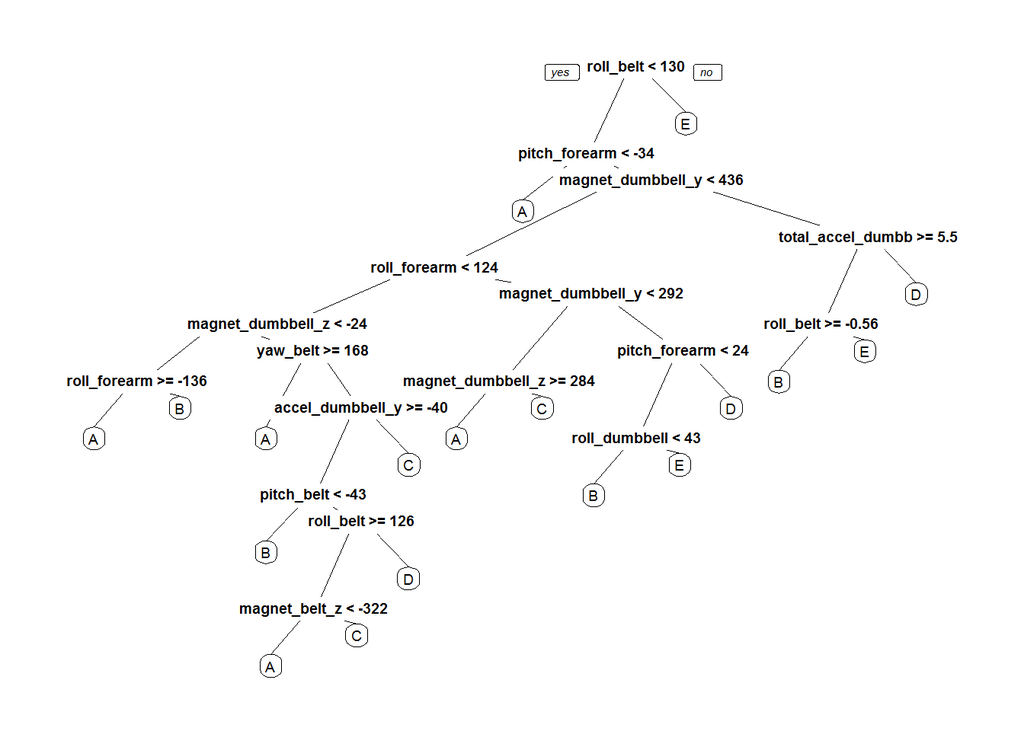

```r
rf <- rpart(classe~., data=training_final, method="class")
prp(rf)
```

Let’s refit the model with this lesser set of the predictors“”

```r
rf_fit2<-randomForest(classe ~ roll_belt + pitch_forearm +magnet_dumbbell_y + total_accel_dumbbell + accel_forearm_x + magnet_dumbbell_z + yaw_belt + roll_forearm + pitch_belt + magnet_belt_z +accel_dumbbell_z + yaw_forearm + roll_dumbbell + magnet_forearm_z, data = training_final, ntree=1000)
rf_result2<-predict(rf_fit2, validation)
confusionMatrix(rf_result2, validation$classe)$overall[1]
```

```
##  Accuracy
## 0.9918434
```

The accuracy seems to be still almost as high. But, the model is much more parsimonious now.

Let’s check importance of all the 52 variables:

```r
Imps<-data.frame(varImp(rf_fit))
Imps$Vars<-row.names(Imps)
rownames(Imps)<-NULL
Imps[order(Imps$Overall, decreasing = T),]
```

```
##      Overall                 Vars
## 1  961.33410            roll_belt
## 3  663.91874             yaw_belt
## 41 573.27018        pitch_forearm
## 39 555.76970    magnet_dumbbell_z
## 2  516.56681           pitch_belt
## 38 505.84711    magnet_dumbbell_y
## 40 469.45080         roll_forearm
## 37 362.95601    magnet_dumbbell_x
## 35 311.96100     accel_dumbbell_y
## 13 305.84510        magnet_belt_z
## 27 304.96944        roll_dumbbell
## 10 300.36011         accel_belt_z
## 12 281.25351        magnet_belt_y
## 47 252.63672      accel_forearm_x
```

[output cut: 38 more lines]

Here is a plot of the variables vs their importance (Gini):

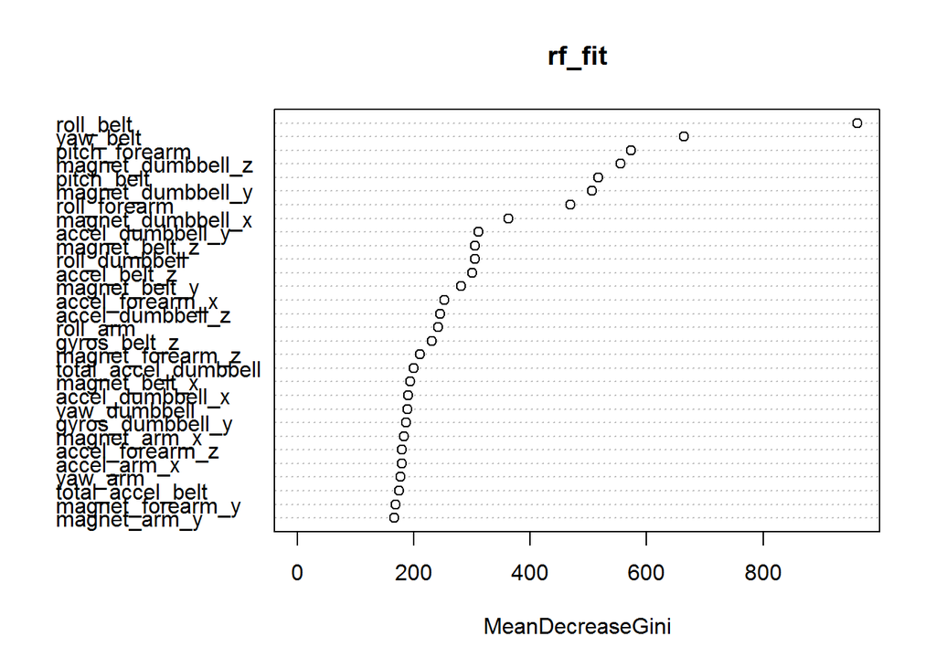

```r
varImpPlot(rf_fit,type=2)
```

```r
rf_fit3<-randomForest(classe ~roll_belt + pitch_belt + yaw_belt + +total_accel_belt + gyros_belt_x + gyros_belt_y + gyros_belt_z + magnet_belt_x + magnet_belt_y + magnet_belt_z + roll_arm , data = training_final, ntree=1000)
rf_result3<-predict(rf_fit3, validation)
confusionMatrix(rf_result3, validation$classe)$overall[1]
```

```
## Accuracy
## 0.942292
```